# Script for applied example in:

Propensity-based standardization to enhance the validation and interpretation of prediction model discrimination for a target population

Authors

Valentijn M.T. de Jong*

Jeroen Hoogland*

Karel G.M. Moons

Richard D. Riley

Tri-Long Nguyen**

Thomas P.A. Debray**

Published

February 26, 2023

Contact

V.M.T.deJong-2@umcutrecht.nl

* Contributed equally and ** Contributed equally

This is a script for reproducing the analyses in the manuscript. As the data are not publicly available, we use the DVTipd dataset in the metamisc R package. As this is a synthetic dataset, the results do not match the results presented in the main manuscript. This script is available from github.com/VMTdeJong/wAUC-applied-example. The code for replicating the simulation study is available from github.com/VMTdeJong/wAUC-sim.

### Functions

We need the following packages. You can also download the wAUC package from github manually and load its functions into R.

```r
library(devtools)
install_github("https://github.com/VMTdeJong/wAUC")
```

```r
library(plyr)
library(wAUC)
library(ggplot2)   # for figures
library(metamisc)  # for meta-analysis
library(nnet)      # multinomial regression
library(knitr)     # for tables
library(gridExtra) # For making one plot with multiple subplots in ggplot2
```

Open the following code block to view the functions we used for meta-analysis.

```r
weighted_validate <- function(model, newdata, weights_name, I = 5000) {
  outcome <- as.character(model$formula[[2]])
  pp <- predict(model, newdata, type = "response")
  lp <- predict(model, newdata, type = "link")
  ws <- newdata[ , weights_name]

  list(auc = wAUC(y = newdata[ , outcome], p = pp, w = ws, I = I))
}

meta_analyze_auc <- function(x, clusters) {
  out <- valmeta(cstat =      unlist(lapply(x, `[[`, "estimate")),
                 cstat.cilb = unlist(lapply(x, `[[`, "ci.lb")),
                 cstat.ciub = unlist(lapply(x, `[[`, "ci.ub")),
                 cstat.cilv = 0.95,
                 slab = clusters)

  if (any(unlist(lapply(x, `[[`, "ci.ub")) < unlist(lapply(x, `[[`, "est"))))
    stop("ci.ub must be greater than the point estimate")

  if (any(unlist(lapply(x, `[[`, "ci.lb")) > unlist(lapply(x, `[[`, "est"))))
    stop("ci.lb must be lower than the point estimate")

  out$tau2 <- out$fit$tau2
  out
}

meta_validate <- function(model, data, cluster_name, weights_name, I = 5000) {
  vals <- list()
  clusters <- sort(unique(data[ , cluster_name]))
  for (cl in seq_along(clusters))
    vals[[cl]] <- weighted_validate(model, data[data[ , cluster_name] %in% clusters[cl], ], weights_name = weights_name, I = I)

  out <- list()
  out$auc   <- meta_analyze_auc(lapply(vals, `[[`,"auc"), clusters)

  out
}

mm_validate <- function(models, data, cluster_name, weights_name, I = 5000) {
  out <- list()
  if (is.null(n <- names(models))) n <- LETTERS
  for (m in seq_along(models))
    out[[n[m]]] <- meta_validate(models[[m]], data, cluster_name, weights_name, I = I)
  out
}
```

And the functions to display results:

```r
paste_est <- function(object, stat, digits, ...)
  with(object[[stat]],
       paste(
         round(est, digits = digits),
         sep = "", ...))

get_est_ci_values <- function(object, stat, digits, ...)
  with(object[[stat]], data.frame(est, ci.lb, ci.ub, pi.lb, pi.ub))

get_df_est_ci <- function(x, stat) {
  names <- data.frame(names = names(lapply(x, get_est_ci_values, stat)))
  values <- Reduce(rbind, lapply(x, get_est_ci_values, stat))
  cbind(names = names, values, model = seq_len(nrow(names)))
}

get_tau_ci_values <- function(object, stat, digits, ...) {
  if (stat == "auc")
    x <- object[[stat]][["fit"]]
  else
    x <- object[[stat]]
  out <- with(x, data.frame(est = tau2,
                            ci.lb = max(0, tau2 + qnorm(.025) * se.tau2),
                            ci.ub =        tau2 + qnorm(.975) * se.tau2))
  sqrt(out)
}


get_df_tau_ci <- function(x, stat) {
  names <- data.frame(names = names(lapply(x, get_tau_ci_values, stat)))
  values <- Reduce(rbind, lapply(x, get_tau_ci_values, stat))
  cbind(names = names, values, model = seq_len(nrow(names)))
}

paste_ci <- function(object, stat, digits, ...)
  with(object[[stat]],
       paste(
         round(ci.lb, digits = digits),
         " : ",
         round(ci.ub, digits = digits),
         sep = "", ...))

paste_pi <- function(object, stat, digits, ...)
  with(object[[stat]],
       paste(
         round(pi.lb, digits = digits),
         " : ",
         round(pi.ub, digits = digits),
         sep = "", ...))

paste_tau <- function(object, stat, digits, ...)
  with(object[[stat]], paste(round(sqrt(tau2), digits = digits), sep = "", ...))


paste_i2 <- function(object, stat, digits, ...)
  paste(round(object[[stat]]$fit$I2, digits = digits), "%", sep = "", ...)

paste_res <- function(x, stat, digits, ...) {
  rbind(
    data.frame(lapply(x, FUN = paste_est, stat = stat, digits = digits), row.names = "Summary estimate"),
    data.frame(lapply(x, FUN = paste_ci,  stat = stat, digits = digits), row.names = "Confidence interval"),
    data.frame(lapply(x, FUN = paste_pi,  stat = stat, digits = digits), row.names = "Prediction interval"),
    data.frame(lapply(x, FUN = paste_tau, stat = stat, digits = digits), row.names = "Tau"),
    data.frame(lapply(x, FUN = paste_i2,  stat = stat, digits = digits), row.names = "I^2"))
}

plot_models <- function(object, statistic, refline = NULL, legend = F, pi = FALSE,
                        legend.position = "bottom") {
  p <- ggplot(object, aes(x = model, y = est, group = weighted, color = weighted))

  # Start with refline, because we want it on the background
  if (!is.null(refline))
    p <- p + geom_hline(mapping = NULL, data = NULL, yintercept = refline, na.rm = FALSE,
                        show.legend = NA, linetype = "dashed")

  p <- p +
    geom_point(aes(shape = weighted), size = 3,
               position=position_dodge(0.25)) +
    scale_x_continuous(breaks = 1:8) +
    geom_errorbar(aes(ymin = ci.lb, ymax = ci.ub), width=.50,
                  position=position_dodge(0.25)) +
    labs(title = "", # title = paste(statistic, " for 8 models in 12 external validation studies", sep = "")
         x="Model", y = statistic) +
    theme_classic() +
    theme(text = element_text(size = 15)) +
    theme(legend.position = legend.position) +
    scale_color_manual(values = c("#FFB000", "#648FFF"))

  if (pi)
    p <- p + geom_errorbar(aes(ymin = pi.lb, ymax = pi.ub), width=.25, size = .25,
                           position=position_dodge(.25))

  p
}

make_table <- function(data,
                       selected_vars = c("sex", "oachst", "malign", "surg", "notraum", "vein", "calfdif3", "ddimdich", "dvt"),
                       new_var_names = c("Male", "Oral contraceptive (OC)", "Presence of malignancy",
                                         "Recent surgery or bedridden", "Absence of leg trauma", "Vein distension",
                                         "Calf difference >= 3cm", "D-dimer abnormal", "DVT presence")) {
  if (nrow(data) == 0L)
    return(NULL)

  data <- as.list(data[ , selected_vars])
  names(data) <- new_var_names
  tab <- t(sapply(data, table))
  colnames(tab) <- c("No", "Yes")
  tab
}

make_table1 <- function(data) {
  tab <- make_table(data)

  # Pct yes
  pct_yes <- cbind("", paste0("(", round(tab[ ,2]/rowSums(tab)*100), "%)"))
  tab[] <- paste0(tab, pct_yes)
  tab
}

min_max_pct <- function(data,
                        cluster) {
  data_sets <- split(data, cluster)
  data_sets[(sapply(data_sets, function(x) nrow(x) == 0))] <- NULL # Removes the empty Oudega study (= dev sample)
  tabs <- lapply(data_sets, make_table)
  pcts <- sapply(tabs, function(x) round(x[ ,2]/rowSums(x)*100))

  mins <- apply(pcts, 1, min)
  maxs <- apply(pcts, 1, max)

  paste0(mins,"% - ", maxs, "%")
}
```

# Data

We define the variable names

```r
cluster <- "study"
predictors <- "sex + oachst + malign + surg + notraum + vein + calfdif3 + ddimdich"

outcome <- "dvt"

cluster_dvl <- "a"
```

Load the data and split into development and validation data.

```r
set.seed(2034482)

data("DVTipd")
dat_dvt <- DVTipd

# Select the development data
dat_dvl <- subset(dat_dvt, study == cluster_dvl)

# Select the validation data
dat_val <- subset(dat_dvt, study != cluster_dvl)
```

#### Table 1

```r
tab1 <- cbind(make_table1(dat_dvl),
              make_table1(dat_val),
              "Range" = min_max_pct(dat_val, dat_val$study))
kable(tab1)
```

|  | No | Yes | No | Yes | Range |
| --- | --- | --- | --- | --- | --- |
| Male | 87 | 59(40%) | 212 | 142(40%) | 37% - 43% |
| Oral contraceptive (OC) | 143 | 3(2%) | 329 | 25(7%) | 6% - 9% |
| Presence of malignancy | 132 | 14(10%) | 328 | 26(7%) | 4% - 10% |
| Recent surgery or bedridden | 127 | 19(13%) | 319 | 35(10%) | 8% - 11% |
| Absence of leg trauma | 28 | 118(81%) | 75 | 279(79%) | 73% - 85% |
| Vein distension | 120 | 26(18%) | 291 | 63(18%) | 17% - 18% |
| Calf difference >= 3cm | 85 | 61(42%) | 230 | 124(35%) | 28% - 44% |
| D-dimer abnormal | 40 | 106(73%) | 150 | 204(58%) | 53% - 65% |
| DVT presence | 119 | 27(18%) | 299 | 55(16%) | 9% - 26% |

# Model development

#### Develop a single model

Fit the prediction model. We do this just to get the order of the size of the coefficients, and their variable names.

```r
fmla_dvl <- paste(outcome, "~", predictors)
fit <- glm(fmla_dvl, data = dat_dvl, family = binomial())
dvl_coefs <- data.frame(Coefficient = names(coef(fit)), Estimate = round(coef(fit), 2), row.names = NULL)
```

#### Develop multiple models

```r
# Sort the variables by coef size
names(sort(coef(fit)[-1], decreasing = T))
```

```
[1] "ddimdich" "calfdif3" "notraum"  "sex"      "vein"     "malign"   "surg"
[8] "oachst"
```

```r
# R has changed the names of the predictors, so here they are manually:
pred_names <- c("ddimdich", "calfdif3", "oachst", "sex", "notraum", "vein", "malign", "surg")

# Create the model formulas accordingly
f_list <- list()
for (i in seq_along(pred_names))
  f_list[[i]] <- formula(dat_dvl[ , c("dvt", pred_names[seq_len(i)]) ])

# Fit the models
m_list <- list()
for (i in seq_along(f_list))
  m_list[[pred_names[i]]] <- glm(f_list[[i]], family = binomial, data = dat_dvl)

# Make table for coefficients of different models
coefs <- do.call(rbind.fill, sapply(m_list, function(x) as.data.frame(matrix(round(coef(x), 3), nrow = 1))))
coefs <- round(coefs, 2)
colnames(coefs) <- c("Intercept", pred_names)
coefs[is.na(coefs)] <- ""
kable(coefs)
```

| Intercept | ddimdich | calfdif3 | oachst | sex | notraum | vein | malign | surg |
| --- | --- | --- | --- | --- | --- | --- | --- | --- |
| -18.57 | 17.49 |  |  |  |  |  |  |  |
| -20.18 | 18.34 | 1.41 |  |  |  |  |  |  |
| -20.18 | 18.38 | 1.4 | -18.4 |  |  |  |  |  |
| -20.64 | 18.54 | 1.28 | -18.02 | 0.88 |  |  |  |  |
| -21.48 | 18.53 | 1.31 | -17.98 | 0.9 | 0.98 |  |  |  |
| -21.64 | 18.58 | 1.19 | -17.9 | 1.04 | 0.97 | 0.64 |  |  |
| -21.77 | 18.65 | 1.23 | -17.96 | 1.09 | 1.06 | 0.71 | -0.68 |  |
| -21.76 | 18.66 | 1.35 | -18.09 | 1.02 | 1.1 | 0.77 | -0.45 | -0.88 |

# Compute propensity weights

```r
fmla_multinom <- paste(cluster, "~", outcome, "+", predictors)
fit_prop <- multinom(fmla_multinom, data = dat_dvt)
n_val_studies <- length(unique(dat_val[,cluster]))
dat_val$prop_dvl <- dat_val$prop_act <- dat_val$w <- NA


for (i in 1:n_val_studies) {
  study_i <- as.character(unique(dat_val[,cluster])[i])

  dat_ps_i <- subset(dat_dvt, study %in% c(cluster_dvl, as.character(unique(dat_val[,cluster])[i])))

  # Calculate LP
  dat_ps_i$lp <- predict(fit, newdata = dat_ps_i, type = "link")

  # Calculate the propensity for being in the development sample
  dat_ps_i$prop_dvl <- predict(fit_prop, newdata = dat_ps_i, type = "probs")[,cluster_dvl] # propensities
  dat_val$prop_dvl[dat_val[,cluster] == study_i] <- dat_ps_i$prop_dvl[dat_ps_i[,cluster] == study_i]

  # Calculate the propensity for being in the current validation sample
  dat_ps_i$prop_val <- predict(fit_prop, newdata = dat_ps_i, type = "probs")[,study_i]
  dat_val$prop_act[dat_val[,cluster] == study_i] <- dat_ps_i$prop_val[dat_ps_i[,cluster] == study_i]
}

# Construct the weights
dat_val$w <- dat_val$prop_dvl/dat_val$prop_act
```

# Model validation

```r
dat_val$unweighted <- 1
I <- 5000
val_unweighd <- mm_validate(m_list, dat_val, "study", "unweighted", I = I)
val_weighted <- mm_validate(m_list, dat_val, "study", "w", I = I)

auc_table_u  <- paste_res(val_unweighd, "auc", digits = 2)
auc_table_w  <- paste_res(val_weighted, "auc", digits = 2)
```

The unweighted estimates are:

```r
kable(auc_table_u)
```

|  | ddimdich | calfdif3 | oachst | sex | notraum | vein | malign | surg |
| --- | --- | --- | --- | --- | --- | --- | --- | --- |
| Summary estimate | 0.72 | 0.78 | 0.75 | 0.78 | 0.78 | 0.79 | 0.78 | 0.77 |
| Confidence interval | 0.55 : 0.84 | 0.75 : 0.81 | 0.72 : 0.79 | 0.72 : 0.83 | 0.73 : 0.83 | 0.69 : 0.87 | 0.62 : 0.88 | 0.66 : 0.85 |
| Prediction interval | 0.13 : 0.98 | 0.67 : 0.86 | 0.63 : 0.84 | 0.59 : 0.9 | 0.6 : 0.9 | 0.42 : 0.95 | 0.27 : 0.97 | 0.39 : 0.95 |
| Tau | 0.14 | 0 | 0 | 0 | 0 | 0 | 0.03 | 0 |
| I^2 | 31.9% | 0% | 0% | 0% | 0% | 0% | 0.66% | 0% |

The weighted estimates are

```r
kable(auc_table_w)
```

|  | ddimdich | calfdif3 | oachst | sex | notraum | vein | malign | surg |
| --- | --- | --- | --- | --- | --- | --- | --- | --- |
| Summary estimate | 0.64 | 0.73 | 0.72 | 0.75 | 0.75 | 0.75 | 0.73 | 0.72 |
| Confidence interval | 0.52 : 0.75 | 0.7 : 0.76 | 0.71 : 0.74 | 0.7 : 0.8 | 0.68 : 0.8 | 0.65 : 0.84 | 0.56 : 0.86 | 0.62 : 0.81 |
| Prediction interval | 0.15 : 0.95 | 0.63 : 0.81 | 0.68 : 0.77 | 0.56 : 0.88 | 0.53 : 0.89 | 0.41 : 0.93 | 0.17 : 0.97 | 0.38 : 0.92 |
| Tau | 0.14 | 0 | 0 | 0 | 0 | 0 | 0.09 | 0 |
| I^2 | 48.56% | 0% | 0% | 0% | 0% | 0% | 8.6% | 0% |

#### Make figure

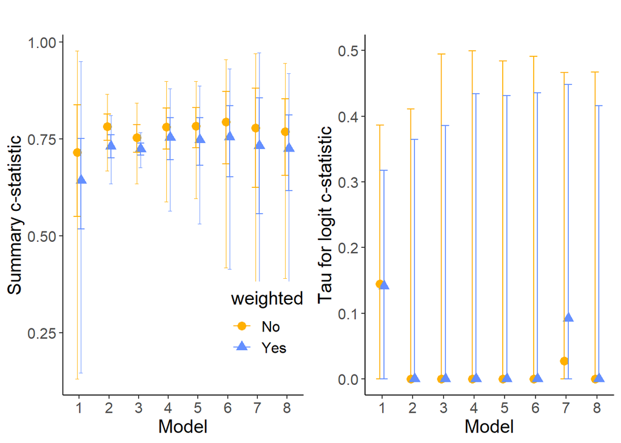

```r
## Point estimates
# c-stat
c.est.ci <- cbind(get_df_est_ci(val_unweighd, "auc"), weighted = F)
c.est.ci <- rbind(c.est.ci, cbind(get_df_est_ci(val_weighted, "auc"), weighted = T))

## Tau
# c-stat
c.tau.ci <- cbind(get_df_tau_ci(val_unweighd, "auc"), weighted = F)
c.tau.ci <- rbind(c.tau.ci, cbind(get_df_tau_ci(val_weighted, "auc"), weighted = T))

### One big figure
# C-stat
c.est.ci$weighted[c.est.ci$weighted == TRUE] <- "Yes"
c.est.ci$weighted[c.est.ci$weighted == "FALSE"] <- "No"

c.tau.ci$weighted[c.tau.ci$weighted == TRUE] <- "Yes"
c.tau.ci$weighted[c.tau.ci$weighted == "FALSE"] <- "No"


p11 <- plot_models(c.est.ci, "Summary c-statistic", legend.position = c(.85, .20), pi = TRUE)
p12 <- plot_models(c.tau.ci, "Tau for logit c-statistic", legend.position = "none")

grid.arrange(p11, p12, ncol = 2)
```

# Footnotes

#### Acknowledgements

This project has received funding from the European Union’s Horizon 2020 research and innovation programme under ReCoDID grant agreement No 825746.

#### Disclaimer

The views expressed in this paper are the personal views of the authors and may not be understood or quoted as being made on behalf of or reflecting the position of the regulatory agency/agencies or organizations with which the authors are employed/affiliated.